# Music and Depression_SurveyAnalysis_Logistic Ordinal Regression

Pietro Mingardi

## Dataset description

(https://www.kaggle.com/datasets/catherinerasgaitis/mxmh-survey-results/data)

Data collection was managed via a Google Form. Respondents were not restricted by age or location. The form was posted in various Reddit forums, Discord servers, and social media platforms. Posters and “business cards” were also used to advertise the form in libraries, parks, and other public locations. The form was relatively brief so that respondents would be more likely finish the survey. “Harder” questions (such as BPM) were left optional for the same reason.

In the survey respondents answer generic questions focused on musical background and listening habits. They rank how often they listen to 16 music genres (they can select: Never, Rarely, Sometimes, Very Frequently). Respondents rank Anxiety, Depression, Insomnia, and OCD on a scale of 0 to 10, where 0 means “I do not experience this” and 10 “I experience this regularly, constantly/or to an extreme”

The sampling method described above, resulted in a self-selected sample. A self-selected sample does not allow to conduct a causal analysis. So, in this report, I want to investigate the association between music and the reported levels of depression. Given the nature of the dependent variable (ordinal) I will use a cumulative ordinal logistic regression model.

```r
data = read.csv("mentalhealth_survey_results.csv")

#trasform "" cells in NA, character columns to factors and Frequency columns to ordinal
freq_levels <- c("Never",
                 "Rarely",
                 "Sometimes",
                 "Very frequently")

data_= data %>%
  mutate(across(where(is.character),
                ~ na_if(.x, ""))) %>%
  mutate(across(starts_with("Frequency"),
                ~ factor(.x, levels = freq_levels, ordered = TRUE))) %>%
  mutate(across(where(is.character),
                as.factor))

#str(data_) #check transformation worked
#summary(data_)
```

**Click here to look the summary of the dataset**

```r
summary(data_)
```

```
##                Timestamp        Age
##  8/28/2022 16:15:08 :  2   Min.   :10.00
##  10/11/2022 15:46:46:  1   1st Qu.:18.00
##  10/14/2022 18:01:12:  1   Median :21.00
##  10/14/2022 20:42:26:  1   Mean   :25.21
##  10/15/2022 14:00:55:  1   3rd Qu.:28.00
##  10/2/2022 7:52:02  :  1   Max.   :89.00
##  (Other)            :729   NA's   :1
##                      Primary.streaming.service Hours.per.day    While.working
##  Apple Music                      : 51         Min.   : 0.000   No  :154
##  I do not use a streaming service.: 71         1st Qu.: 2.000   Yes :579
##  Other streaming service          : 50         Median : 3.000   NA's:  3
##  Pandora                          : 11         Mean   : 3.573
##  Spotify                          :458         3rd Qu.: 5.000
##  YouTube Music                    : 94         Max.   :24.000
##  NA's                             :  1
##  Instrumentalist Composer              Fav.genre   Exploratory
##  No  :497        No  :609   Rock            :188   No :211
##  Yes :235        Yes :126   Pop             :114   Yes:525
##  NA's:  4        NA's:  1   Metal           : 88
##                             Classical       : 53
##                             Video game music: 44
##                             EDM             : 37
##                             (Other)         :212
##  Foreign.languages      BPM                Frequency..Classical.
##  No  :328          Min.   :        0   Never          :169
##  Yes :404          1st Qu.:      100   Rarely         :259
##  NA's:  4          Median :      120   Sometimes      :200
##                    Mean   :  1589948   Very frequently:108
##                    3rd Qu.:      144
##                    Max.   :999999999
##                    NA's   :107
##       Frequency..Country.        Frequency..EDM.        Frequency..Folk.
##  Never          :343      Never          :307    Never          :292
##  Rarely         :233      Rarely         :194    Rarely         :221
##  Sometimes      :111      Sometimes      :146    Sometimes      :145
##  Very frequently: 49      Very frequently: 89    Very frequently: 78
##
##
##
```

[output cut: 33 more lines]

```
##  Min.   : 0.000   Min.   : 0.000   Min.   : 0.000   Min.   : 0.000
##  1st Qu.: 4.000   1st Qu.: 2.000   1st Qu.: 1.000   1st Qu.: 0.000
##  Median : 6.000   Median : 5.000   Median : 3.000   Median : 2.000
##  Mean   : 5.838   Mean   : 4.796   Mean   : 3.738   Mean   : 2.637
##  3rd Qu.: 8.000   3rd Qu.: 7.000   3rd Qu.: 6.000   3rd Qu.: 5.000
##  Max.   :10.000   Max.   :10.000   Max.   :10.000   Max.   :10.000
##
##    Music.effects        Permissions
##  Improve  :542   I understand.:736
##  No effect:169
##  Worsen   : 17
##  NA's     :  8
##
##
##
```

## Sample description

From the summary of the dataset we can see that 736 volunteers took part in the survey. Their mean age was 25.21 (range = [10, 89]). The most popular streaming app among respondents was Spotify: 458 out of 736 people reported it as their primary streaming service and in median participants reported to listen music for three hours. 579 participants reported to listen music also while working. 235 participants reported to be instrumentalist and 126 composer. The favourite genre reported (among 16 possible options) was Rock (188) followed by Pop (114). 542 respondent said to believe music has a positive impact on their mental health, only 17 said to think it has a bad impact.

## Dependent variable

```r
#distribution of Depression variable
table(data_$Depression)
```

```
##
##   0   1   2   3 3.5   4   5   6   7   8   9  10
##  84  40  93  59   2  58  56  88  96  77  38  45
```

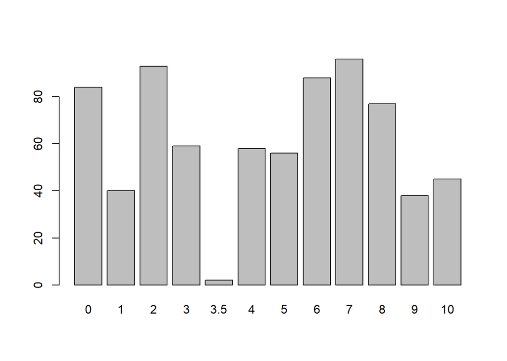

```r
#prop.table(table(data_$Depression)) #relative frequency distribution
barplot(table(data_$Depression))
```

```r
#Two responses were non-integer (3.5) and were rounded to the nearest integer
data_$Depression <- round(data_$Depression)
#table(data_$Depression) #check rounding worked

data_$Depression_ord <- factor(data_$Depression,
                               ordered = TRUE)
```

# Exploratory factor analysis and columns selection

To study the association between music and depression, variables representing musical habits and music background were selected. Moreover, Age was included as a control variable, given that it can be associated both to depression and musical habits.

Reagarding musical habits variables, the column Fav.genre captures a single self-reported preferred genre, while Frequency.* items capture a broader listening profile across genres. To reduce dimensionality and minimize multicollinearity, only the Frequency.* items were retained. An exploratory factor analysis (EFA) was then conducted to extract latent listening-pattern factors.

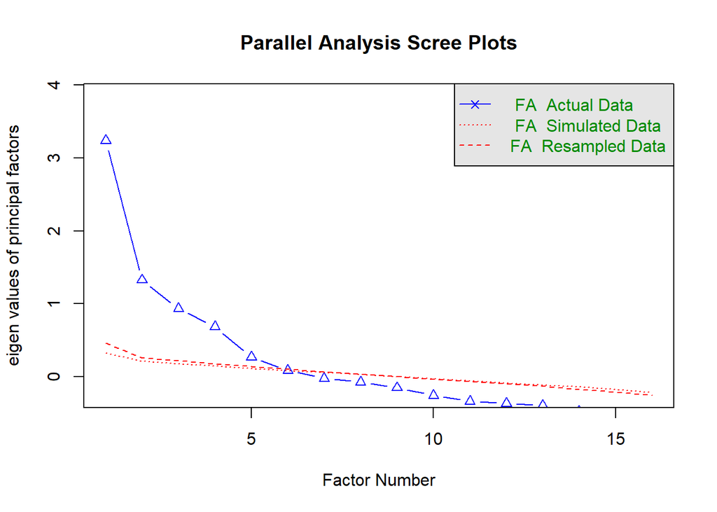

```
## Parallel analysis suggests that the number of factors =  5  and the number of components =  NA
```

```r
freq_vars <- data_[, grepl("^Frequency", names(data_))]

#transform to numeric
freq_num <- freq_vars %>%
  mutate(across(everything(), as.numeric))

#run parallel analysis to identify the number of factors
fa.parallel(freq_num,
            fa = "fa",
            fm = "minres",
            cor = "poly")
```

```r
#Despite parallel analysis suggests 5 factors, for parsimony and interpretability 2 factors are retained.
fa2 <- fa(
  freq_num,
  nfactors = 2,
  fm = "minres",
  rotate = "oblimin",
  cor = "poly"
)#run factorial analysis, with oblimin rotation (factors can correlate) and polychoric correlation (ordinal data)
```

```
## Caricamento dei namespace richiesti: GPArotation
```

```r
print(fa2$loadings, cutoff = 0.30) #display only factors loading grater than 0.3
```

```
##
## Loadings:
##                              MR1    MR2
## Frequency..Classical.
## Frequency..Country.                  0.390
## Frequency..EDM.               0.348
## Frequency..Folk.                     0.648
## Frequency..Gospel.            0.333
## Frequency..Hip.hop.           0.768
## Frequency..Jazz.              0.410
## Frequency..K.pop.             0.558
## Frequency..Latin.             0.518
## Frequency..Lofi.              0.512
## Frequency..Metal.                    0.612
## Frequency..Pop.               0.504
## Frequency..R.B.               0.780
## Frequency..Rap.               0.694
## Frequency..Rock.                     0.715
## Frequency..Video.game.music.
##
##                  MR1   MR2
## SS loadings    3.253 1.681
## Proportion Var 0.203 0.105
## Cumulative Var 0.203 0.308
```

```r
#estimate factor scores for each participant
scores2 <- factor.scores(freq_num, fa2, method = "tenBerge")
data_$Urban <- scores2$scores[,1] #the first facor is Urban music
data_$RockMetal <- scores2$scores[,2] #the second factor in ROckMetal music


#select model varibles
model_vars <- c("Age", "Depression_ord", "Hours.per.day", "While.working",
                "Exploratory", "Instrumentalist", "Composer", "Urban", "RockMetal",
                "Foreign.languages")

dat_mod <- data_[,model_vars] %>% na.omit() #eliminaimo NA

print(paste("number of participants after removing NA rows:", nrow(dat_mod)))
```

```
## [1] "number of participants after removing NA rows: 726"
```

# Model fitting

```r
#numerical columns are standardized while categorical are effect coded in order to allow comparisons
#among coefficients estimated and interpretion of main effects from the summary of the model
contrasts(dat_mod$While.working) <-  matrix(c(-0.5, 0.5), ncol = 1)
contrasts(dat_mod$Exploratory) <-  matrix(c(-0.5, 0.5), ncol = 1)
contrasts(dat_mod$Instrumentalist) <-  matrix(c(-0.5, 0.5), ncol = 1)
contrasts(dat_mod$Composer) <-  matrix(c(-0.5, 0.5), ncol = 1)
contrasts(dat_mod$Foreign.languages) <-  matrix(c(-0.5, 0.5), ncol = 1)
dat_mod$Age <- scale(dat_mod$Age)
dat_mod$Hours.per.day <- scale(dat_mod$Hours.per.day)


model <- clm(
  Depression_ord ~ Age +
    Hours.per.day +
    While.working +
    Exploratory +
    Instrumentalist +
    Composer +
    Urban +
    RockMetal +
    Foreign.languages,
  data = dat_mod
)
summary(model)
```

```
## formula:
## Depression_ord ~ Age + Hours.per.day + While.working + Exploratory + Instrumentalist + Composer + Urban + RockMetal + Foreign.languages
## data:    dat_mod
##
##  link  threshold nobs logLik   AIC     niter max.grad cond.H
##  logit flexible  726  -1681.83 3401.67 6(0)  2.66e-10 2.3e+02
##
## Coefficients:
##                    Estimate Std. Error z value    Pr(>|z|)
## Age                -0.23785    0.06765  -3.516    0.000439 ***
## Hours.per.day       0.12430    0.07640   1.627    0.103751
## While.working1      0.04959    0.16986   0.292    0.770302
## Exploratory1       -0.09555    0.15515  -0.616    0.537961
## Instrumentalist1   -0.09101    0.15445  -0.589    0.555711
## Composer1           0.11977    0.19155   0.625    0.531783
## Urban               0.09225    0.07190   1.283    0.199492
## RockMetal           0.34008    0.06930   4.907 0.000000924 ***
## Foreign.languages1  0.17722    0.13851   1.280    0.200709
## ---
## Signif. codes:  0 '***' 0.001 '**' 0.01 '*' 0.05 '.' 0.1 ' ' 1
##
## Threshold coefficients:
##      Estimate Std. Error z value
## 0|1   -2.1635     0.1450 -14.925
## 1|2   -1.6901     0.1307 -12.933
## 2|3   -0.9338     0.1172  -7.969
## 3|4   -0.5619     0.1139  -4.933
## 4|5   -0.2033     0.1127  -1.804
## 5|6    0.1154     0.1128   1.022
## 6|7    0.6338     0.1152   5.503
## 7|8    1.3014     0.1237  10.519
## 8|9    2.1134     0.1451  14.568
## 9|10   2.8070     0.1772  15.839
```

```r
drop1(model, test="Chisq") #use the drop method to asses significance of the predictors
```

```
## Single term deletions
##
## Model:
## Depression_ord ~ Age + Hours.per.day + While.working + Exploratory +
##     Instrumentalist + Composer + Urban + RockMetal + Foreign.languages
##                   Df    AIC     LRT     Pr(>Chi)
## <none>               3401.7
## Age                1 3411.9 12.2501    0.0004652 ***
## Hours.per.day      1 3402.4  2.7004    0.1003229
## While.working      1 3399.8  0.0853    0.7703009
## Exploratory        1 3400.0  0.3795    0.5378667
## Instrumentalist    1 3400.0  0.3473    0.5556557
## Composer           1 3400.1  0.3911    0.5317414
## Urban              1 3401.3  1.6487    0.1991409
## RockMetal          1 3424.1 24.4046 0.0000007808 ***
## Foreign.languages  1 3401.3  1.6384    0.2005519
## ---
## Signif. codes:  0 '***' 0.001 '**' 0.01 '*' 0.05 '.' 0.1 ' ' 1
```

```r
#extract Odds-Ratio of the predictors
OR = exp(model$beta)
CI = exp(confint(model)[names(model$beta),,drop = FALSE])

tab_or <- cbind(OR, CI)
tab_or
```

```
##                           OR     2.5 %    97.5 %
## Age                0.7883189 0.6903210 0.9002739
## Hours.per.day      1.1323526 0.9765697 1.3179014
## While.working1     1.0508452 0.7531694 1.4662815
## Exploratory1       0.9088695 0.6702934 1.2316993
## Instrumentalist1   0.9130099 0.6743167 1.2357458
## Composer1          1.1272412 0.7743694 1.6415648
## Urban              1.0966423 0.9526280 1.2629569
## RockMetal          1.4050608 1.2271646 1.6104229
## Foreign.languages1 1.1938983 0.9101644 1.5667218
```

```r
nominal_test(model) #check cml assumption of proportional odds.
```

```
## Tests of nominal effects
##
## formula: Depression_ord ~ Age + Hours.per.day + While.working + Exploratory + Instrumentalist + Composer + Urban + RockMetal + Foreign.languages
##                   Df  logLik    AIC     LRT Pr(>Chi)
## <none>               -1681.8 3401.7
## Age                9 -1679.9 3415.9  3.8181   0.9230
## Hours.per.day      9 -1675.1 3406.2 13.4245   0.1443
## While.working      9 -1675.0 3406.1 13.5815   0.1380
## Exploratory        9 -1674.3 3404.6 15.0974   0.0883 .
## Instrumentalist    9 -1677.0 3410.0  9.6512   0.3795
## Composer           9 -1679.5 3415.1  4.5669   0.8703
## Urban              9 -1677.0 3410.1  9.6058   0.3833
## RockMetal          9 -1676.8 3409.7 10.0036   0.3502
## Foreign.languages  9 -1677.2 3410.3  9.3223   0.4081
## ---
## Signif. codes:  0 '***' 0.001 '**' 0.01 '*' 0.05 '.' 0.1 ' ' 1
```

```r
#assumptions are met
```

# Interpretation of the results

The analysis showed that, among the music variables, listening RockMetal music is associated with higher depression ratings [beta = 0.34, OR = 1.40, C.I = [1,23 - 1.61]]